# Project - COVID19

## 1.4 Correlation

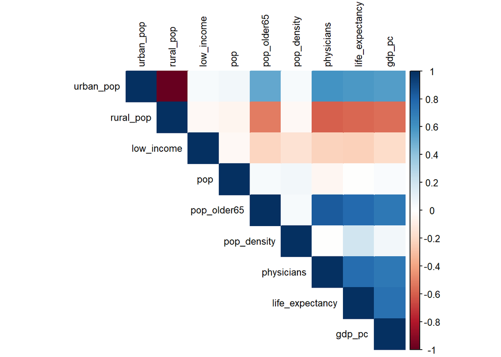

The correlation matrix reveals clear structural relationships among the socio-economic indicators. Urban and rural population shares show a strong negative correlation, indicating they measure opposite aspects of the same distribution and therefore provide redundant information. A group of variables—GDP per capita, life expectancy, physician density, and the share of older adults—form a strongly positive cluster. This pattern reflects a broader development profile: wealthier countries tend to have stronger healthcare systems, longer life expectancy, and older populations.

Conversely, the share of low-income population is negatively correlated with this cluster, consistent with reduced healthcare access and shorter lifespans in lower-income settings. In contrast, population size and population density show only weak correlations with the other variables, suggesting that country size alone does not determine development or health outcomes.